# Risk Factor Analysis

## Outcome Variable

**Outcome Variable:** ever_swasted

## Predictor Variables

**Intervention Variable:** birthlen

**Adjustment Set:**

unadjusted

## Stratifying Variables

The analysis was stratified on these variable(s):

- agecat
- studyid
- country

## Data Summary

| agecat | studyid | country | birthlen | ever_swasted | n_cell | n |
| --- | --- | --- | --- | --- | --- | --- |
| 0-24 months (no birth wast) | CMC-V-BCS-2002 | INDIA | >=50 cm | 0 | 13 | 104 |
| 0-24 months (no birth wast) | CMC-V-BCS-2002 | INDIA | >=50 cm | 1 | 3 | 104 |
| 0-24 months (no birth wast) | CMC-V-BCS-2002 | INDIA | <48 cm | 0 | 36 | 104 |
| 0-24 months (no birth wast) | CMC-V-BCS-2002 | INDIA | <48 cm | 1 | 12 | 104 |
| 0-24 months (no birth wast) | CMC-V-BCS-2002 | INDIA | [48-50) cm | 0 | 34 | 104 |
| 0-24 months (no birth wast) | CMC-V-BCS-2002 | INDIA | [48-50) cm | 1 | 6 | 104 |
| 0-24 months (no birth wast) | CMIN | BANGLADESH | >=50 cm | 0 | 1 | 17 |
| 0-24 months (no birth wast) | CMIN | BANGLADESH | >=50 cm | 1 | 0 | 17 |
| 0-24 months (no birth wast) | CMIN | BANGLADESH | <48 cm | 0 | 8 | 17 |
| 0-24 months (no birth wast) | CMIN | BANGLADESH | <48 cm | 1 | 0 | 17 |
| 0-24 months (no birth wast) | CMIN | BANGLADESH | [48-50) cm | 0 | 8 | 17 |
| 0-24 months (no birth wast) | CMIN | BANGLADESH | [48-50) cm | 1 | 0 | 17 |
| 0-24 months (no birth wast) | COHORTS | GUATEMALA | >=50 cm | 0 | 418 | 821 |
| 0-24 months (no birth wast) | COHORTS | GUATEMALA | >=50 cm | 1 | 2 | 821 |
| 0-24 months (no birth wast) | COHORTS | GUATEMALA | <48 cm | 0 | 149 | 821 |
| 0-24 months (no birth wast) | COHORTS | GUATEMALA | <48 cm | 1 | 6 | 821 |
| 0-24 months (no birth wast) | COHORTS | GUATEMALA | [48-50) cm | 0 | 243 | 821 |
| 0-24 months (no birth wast) | COHORTS | GUATEMALA | [48-50) cm | 1 | 3 | 821 |
| 0-24 months (no birth wast) | COHORTS | INDIA | >=50 cm | 0 | 1349 | 6400 |
| 0-24 months (no birth wast) | COHORTS | INDIA | >=50 cm | 1 | 40 | 6400 |
| 0-24 months (no birth wast) | COHORTS | INDIA | <48 cm | 0 | 2473 | 6400 |
| 0-24 months (no birth wast) | COHORTS | INDIA | <48 cm | 1 | 171 | 6400 |
| 0-24 months (no birth wast) | COHORTS | INDIA | [48-50) cm | 0 | 2249 | 6400 |
| 0-24 months (no birth wast) | COHORTS | INDIA | [48-50) cm | 1 | 118 | 6400 |
| 0-24 months (no birth wast) | COHORTS | PHILIPPINES | >=50 cm | 0 | 1044 | 3011 |
| 0-24 months (no birth wast) | COHORTS | PHILIPPINES | >=50 cm | 1 | 77 | 3011 |
| 0-24 months (no birth wast) | COHORTS | PHILIPPINES | <48 cm | 0 | 674 | 3011 |
| 0-24 months (no birth wast) | COHORTS | PHILIPPINES | <48 cm | 1 | 66 | 3011 |
| 0-24 months (no birth wast) | COHORTS | PHILIPPINES | [48-50) cm | 0 | 1044 | 3011 |
| 0-24 months (no birth wast) | COHORTS | PHILIPPINES | [48-50) cm | 1 | 106 | 3011 |

[output cut: 438 more lines]

The following strata were considered:

- agecat: 0-24 months (no birth wast), studyid: CMC-V-BCS-2002, country: INDIA
- agecat: 0-24 months (no birth wast), studyid: CMIN, country: BANGLADESH
- agecat: 0-24 months (no birth wast), studyid: COHORTS, country: GUATEMALA
- agecat: 0-24 months (no birth wast), studyid: COHORTS, country: INDIA
- agecat: 0-24 months (no birth wast), studyid: COHORTS, country: PHILIPPINES
- agecat: 0-24 months (no birth wast), studyid: CONTENT, country: PERU
- agecat: 0-24 months (no birth wast), studyid: EE, country: PAKISTAN
- agecat: 0-24 months (no birth wast), studyid: GMS-Nepal, country: NEPAL
- agecat: 0-24 months (no birth wast), studyid: IRC, country: INDIA
- agecat: 0-24 months (no birth wast), studyid: JiVitA-3, country: BANGLADESH
- agecat: 0-24 months (no birth wast), studyid: JiVitA-4, country: BANGLADESH
- agecat: 0-24 months (no birth wast), studyid: Keneba, country: GAMBIA
- agecat: 0-24 months (no birth wast), studyid: MAL-ED, country: BANGLADESH
- agecat: 0-24 months (no birth wast), studyid: MAL-ED, country: BRAZIL
- agecat: 0-24 months (no birth wast), studyid: MAL-ED, country: INDIA
- agecat: 0-24 months (no birth wast), studyid: MAL-ED, country: NEPAL
- agecat: 0-24 months (no birth wast), studyid: MAL-ED, country: PERU
- agecat: 0-24 months (no birth wast), studyid: MAL-ED, country: SOUTH AFRICA
- agecat: 0-24 months (no birth wast), studyid: MAL-ED, country: TANZANIA, UNITED REPUBLIC OF
- agecat: 0-24 months (no birth wast), studyid: NIH-Birth, country: BANGLADESH
- agecat: 0-24 months (no birth wast), studyid: NIH-Crypto, country: BANGLADESH
- agecat: 0-24 months (no birth wast), studyid: PROBIT, country: BELARUS
- agecat: 0-24 months (no birth wast), studyid: PROVIDE, country: BANGLADESH
- agecat: 0-24 months (no birth wast), studyid: ResPak, country: PAKISTAN
- agecat: 0-24 months (no birth wast), studyid: SAS-CompFeed, country: INDIA
- agecat: 0-24 months (no birth wast), studyid: ZVITAMBO, country: ZIMBABWE
- agecat: 0-6 months (no birth wast), studyid: CMC-V-BCS-2002, country: INDIA
- agecat: 0-6 months (no birth wast), studyid: CMIN, country: BANGLADESH
- agecat: 0-6 months (no birth wast), studyid: COHORTS, country: GUATEMALA
- agecat: 0-6 months (no birth wast), studyid: COHORTS, country: INDIA
- agecat: 0-6 months (no birth wast), studyid: COHORTS, country: PHILIPPINES
- agecat: 0-6 months (no birth wast), studyid: CONTENT, country: PERU
- agecat: 0-6 months (no birth wast), studyid: EE, country: PAKISTAN
- agecat: 0-6 months (no birth wast), studyid: GMS-Nepal, country: NEPAL
- agecat: 0-6 months (no birth wast), studyid: IRC, country: INDIA
- agecat: 0-6 months (no birth wast), studyid: JiVitA-3, country: BANGLADESH
- agecat: 0-6 months (no birth wast), studyid: JiVitA-4, country: BANGLADESH
- agecat: 0-6 months (no birth wast), studyid: Keneba, country: GAMBIA
- agecat: 0-6 months (no birth wast), studyid: MAL-ED, country: BANGLADESH
- agecat: 0-6 months (no birth wast), studyid: MAL-ED, country: BRAZIL
- agecat: 0-6 months (no birth wast), studyid: MAL-ED, country: INDIA
- agecat: 0-6 months (no birth wast), studyid: MAL-ED, country: NEPAL
- agecat: 0-6 months (no birth wast), studyid: MAL-ED, country: PERU
- agecat: 0-6 months (no birth wast), studyid: MAL-ED, country: SOUTH AFRICA
- agecat: 0-6 months (no birth wast), studyid: MAL-ED, country: TANZANIA, UNITED REPUBLIC OF
- agecat: 0-6 months (no birth wast), studyid: NIH-Birth, country: BANGLADESH
- agecat: 0-6 months (no birth wast), studyid: NIH-Crypto, country: BANGLADESH
- agecat: 0-6 months (no birth wast), studyid: PROBIT, country: BELARUS
- agecat: 0-6 months (no birth wast), studyid: PROVIDE, country: BANGLADESH
- agecat: 0-6 months (no birth wast), studyid: ResPak, country: PAKISTAN
- agecat: 0-6 months (no birth wast), studyid: SAS-CompFeed, country: INDIA
- agecat: 0-6 months (no birth wast), studyid: ZVITAMBO, country: ZIMBABWE
- agecat: 6-24 months, studyid: CMC-V-BCS-2002, country: INDIA
- agecat: 6-24 months, studyid: CMIN, country: BANGLADESH
- agecat: 6-24 months, studyid: COHORTS, country: GUATEMALA
- agecat: 6-24 months, studyid: COHORTS, country: INDIA
- agecat: 6-24 months, studyid: COHORTS, country: PHILIPPINES
- agecat: 6-24 months, studyid: CONTENT, country: PERU
- agecat: 6-24 months, studyid: EE, country: PAKISTAN
- agecat: 6-24 months, studyid: GMS-Nepal, country: NEPAL
- agecat: 6-24 months, studyid: IRC, country: INDIA
- agecat: 6-24 months, studyid: JiVitA-3, country: BANGLADESH
- agecat: 6-24 months, studyid: JiVitA-4, country: BANGLADESH
- agecat: 6-24 months, studyid: Keneba, country: GAMBIA
- agecat: 6-24 months, studyid: MAL-ED, country: BANGLADESH
- agecat: 6-24 months, studyid: MAL-ED, country: BRAZIL
- agecat: 6-24 months, studyid: MAL-ED, country: INDIA
- agecat: 6-24 months, studyid: MAL-ED, country: NEPAL
- agecat: 6-24 months, studyid: MAL-ED, country: PERU
- agecat: 6-24 months, studyid: MAL-ED, country: SOUTH AFRICA
- agecat: 6-24 months, studyid: MAL-ED, country: TANZANIA, UNITED REPUBLIC OF
- agecat: 6-24 months, studyid: NIH-Birth, country: BANGLADESH
- agecat: 6-24 months, studyid: NIH-Crypto, country: BANGLADESH
- agecat: 6-24 months, studyid: PROBIT, country: BELARUS
- agecat: 6-24 months, studyid: PROVIDE, country: BANGLADESH
- agecat: 6-24 months, studyid: ResPak, country: PAKISTAN
- agecat: 6-24 months, studyid: SAS-CompFeed, country: INDIA
- agecat: 6-24 months, studyid: ZVITAMBO, country: ZIMBABWE

### Dropped Strata

Some strata were dropped due to rare outcomes:

- agecat: 0-24 months (no birth wast), studyid: CMC-V-BCS-2002, country: INDIA
- agecat: 0-24 months (no birth wast), studyid: CMIN, country: BANGLADESH
- agecat: 0-24 months (no birth wast), studyid: COHORTS, country: GUATEMALA
- agecat: 0-24 months (no birth wast), studyid: CONTENT, country: PERU
- agecat: 0-24 months (no birth wast), studyid: MAL-ED, country: BANGLADESH
- agecat: 0-24 months (no birth wast), studyid: MAL-ED, country: BRAZIL
- agecat: 0-24 months (no birth wast), studyid: MAL-ED, country: INDIA
- agecat: 0-24 months (no birth wast), studyid: MAL-ED, country: NEPAL
- agecat: 0-24 months (no birth wast), studyid: MAL-ED, country: PERU
- agecat: 0-24 months (no birth wast), studyid: MAL-ED, country: SOUTH AFRICA
- agecat: 0-24 months (no birth wast), studyid: MAL-ED, country: TANZANIA, UNITED REPUBLIC OF
- agecat: 0-24 months (no birth wast), studyid: NIH-Crypto, country: BANGLADESH
- agecat: 0-24 months (no birth wast), studyid: PROBIT, country: BELARUS
- agecat: 0-24 months (no birth wast), studyid: PROVIDE, country: BANGLADESH
- agecat: 0-24 months (no birth wast), studyid: ResPak, country: PAKISTAN
- agecat: 0-6 months (no birth wast), studyid: CMC-V-BCS-2002, country: INDIA
- agecat: 0-6 months (no birth wast), studyid: CMIN, country: BANGLADESH
- agecat: 0-6 months (no birth wast), studyid: COHORTS, country: GUATEMALA
- agecat: 0-6 months (no birth wast), studyid: CONTENT, country: PERU
- agecat: 0-6 months (no birth wast), studyid: EE, country: PAKISTAN
- agecat: 0-6 months (no birth wast), studyid: GMS-Nepal, country: NEPAL
- agecat: 0-6 months (no birth wast), studyid: JiVitA-4, country: BANGLADESH
- agecat: 0-6 months (no birth wast), studyid: MAL-ED, country: BANGLADESH
- agecat: 0-6 months (no birth wast), studyid: MAL-ED, country: BRAZIL
- agecat: 0-6 months (no birth wast), studyid: MAL-ED, country: INDIA
- agecat: 0-6 months (no birth wast), studyid: MAL-ED, country: NEPAL
- agecat: 0-6 months (no birth wast), studyid: MAL-ED, country: PERU
- agecat: 0-6 months (no birth wast), studyid: MAL-ED, country: SOUTH AFRICA
- agecat: 0-6 months (no birth wast), studyid: MAL-ED, country: TANZANIA, UNITED REPUBLIC OF
- agecat: 0-6 months (no birth wast), studyid: NIH-Birth, country: BANGLADESH
- agecat: 0-6 months (no birth wast), studyid: NIH-Crypto, country: BANGLADESH
- agecat: 0-6 months (no birth wast), studyid: PROBIT, country: BELARUS
- agecat: 0-6 months (no birth wast), studyid: PROVIDE, country: BANGLADESH
- agecat: 0-6 months (no birth wast), studyid: ResPak, country: PAKISTAN
- agecat: 0-6 months (no birth wast), studyid: SAS-CompFeed, country: INDIA
- agecat: 6-24 months, studyid: CMC-V-BCS-2002, country: INDIA
- agecat: 6-24 months, studyid: CMIN, country: BANGLADESH
- agecat: 6-24 months, studyid: COHORTS, country: GUATEMALA
- agecat: 6-24 months, studyid: CONTENT, country: PERU
- agecat: 6-24 months, studyid: EE, country: PAKISTAN
- agecat: 6-24 months, studyid: MAL-ED, country: BANGLADESH
- agecat: 6-24 months, studyid: MAL-ED, country: BRAZIL
- agecat: 6-24 months, studyid: MAL-ED, country: INDIA
- agecat: 6-24 months, studyid: MAL-ED, country: NEPAL
- agecat: 6-24 months, studyid: MAL-ED, country: PERU
- agecat: 6-24 months, studyid: MAL-ED, country: SOUTH AFRICA
- agecat: 6-24 months, studyid: MAL-ED, country: TANZANIA, UNITED REPUBLIC OF
- agecat: 6-24 months, studyid: NIH-Crypto, country: BANGLADESH
- agecat: 6-24 months, studyid: PROBIT, country: BELARUS
- agecat: 6-24 months, studyid: PROVIDE, country: BANGLADESH
- agecat: 6-24 months, studyid: ResPak, country: PAKISTAN

## Methods Detail

We’re interested in the causal parameters $E[Y_a]$ for all values of $a \in \mathcal{A}$. These parameters represent the mean outcome if, possibly contrary to fact, we intervened to set all units to have $A=a$. Under the randomization and positivity assumptions, these are identified by the statistical parameters $\psi_a=E_W[E_{Y|A,W}(Y|A=a,W)]$. In addition, we’re interested in the mean of $Y$, $E[Y]$ under no intervention (the observed mean). We will estimate these parameters by using SuperLearner to fit the relevant likelihood factors – $E_{Y|A,W}(Y|A=a,W)$ and $p(A=a|W)$, and then updating our likelihood fit using a joint TMLE.

For unadjusted analyses ($W=\{\}$), initial likelihoods were estimated using Lrnr_glm to estimate the simple $E(Y|A)$ and Lrnr_mean to estimate $p(A)$. For adjusted analyses, a small library containing Lrnr_glmnet, Lrnr_xgboost, and Lrnr_mean was used.

Having estimated these parameters, we will then use the delta method to estimate relative risks and attributable risks relative to a prespecified baseline level of $A$.

# Results Detail

## Results Plots

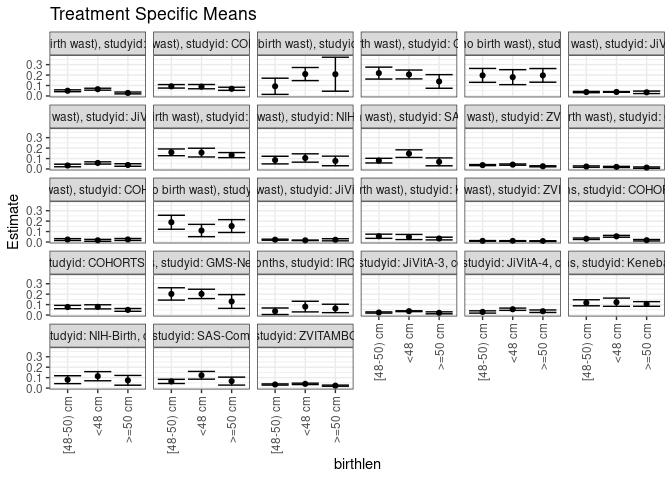

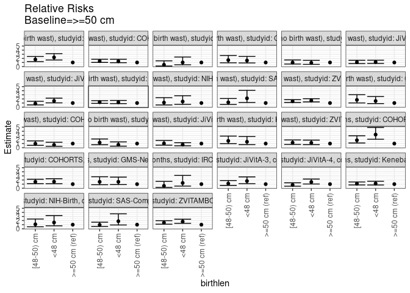

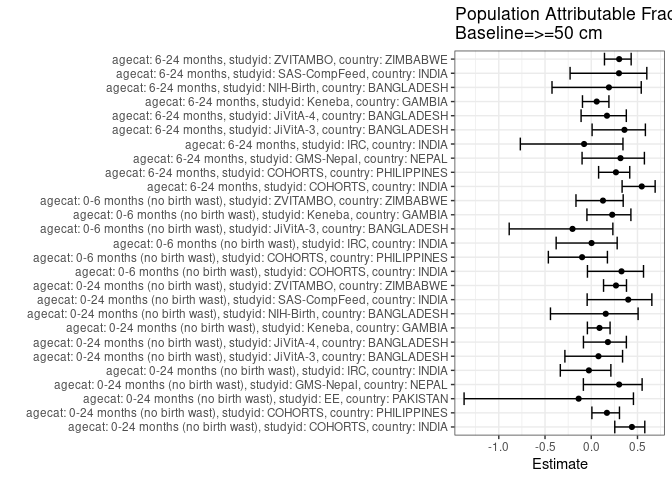

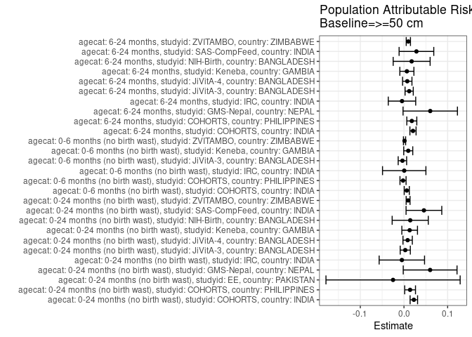

## Results Table

### Parameter: TSM

| agecat | studyid | country | intervention_level | baseline_level | estimate | ci_lower | ci_upper |
| --- | --- | --- | --- | --- | --- | --- | --- |
| 0-24 months (no birth wast) | COHORTS | INDIA | >=50 cm | NA | 0.0287977 | 0.0200021 | 0.0375933 |
| 0-24 months (no birth wast) | COHORTS | INDIA | <48 cm | NA | 0.0646747 | 0.0552991 | 0.0740504 |
| 0-24 months (no birth wast) | COHORTS | INDIA | [48-50) cm | NA | 0.0498521 | 0.0410837 | 0.0586205 |
| 0-24 months (no birth wast) | COHORTS | PHILIPPINES | >=50 cm | NA | 0.0686887 | 0.0538803 | 0.0834970 |
| 0-24 months (no birth wast) | COHORTS | PHILIPPINES | <48 cm | NA | 0.0891892 | 0.0686504 | 0.1097280 |
| 0-24 months (no birth wast) | COHORTS | PHILIPPINES | [48-50) cm | NA | 0.0921739 | 0.0754524 | 0.1088955 |
| 0-24 months (no birth wast) | EE | PAKISTAN | >=50 cm | NA | 0.2083333 | 0.0455164 | 0.3711503 |
| 0-24 months (no birth wast) | EE | PAKISTAN | <48 cm | NA | 0.2098765 | 0.1470379 | 0.2727152 |
| 0-24 months (no birth wast) | EE | PAKISTAN | [48-50) cm | NA | 0.0925926 | 0.0151202 | 0.1700650 |
| 0-24 months (no birth wast) | GMS-Nepal | NEPAL | >=50 cm | NA | 0.1388889 | 0.0736165 | 0.2041612 |
| 0-24 months (no birth wast) | GMS-Nepal | NEPAL | <48 cm | NA | 0.2057143 | 0.1633339 | 0.2480946 |
| 0-24 months (no birth wast) | GMS-Nepal | NEPAL | [48-50) cm | NA | 0.2189055 | 0.1616971 | 0.2761139 |
| 0-24 months (no birth wast) | IRC | INDIA | >=50 cm | NA | 0.1971831 | 0.1316585 | 0.2627077 |
| 0-24 months (no birth wast) | IRC | INDIA | <48 cm | NA | 0.1801802 | 0.1085894 | 0.2517709 |
| 0-24 months (no birth wast) | IRC | INDIA | [48-50) cm | NA | 0.1970803 | 0.1303838 | 0.2637768 |
| 0-24 months (no birth wast) | JiVitA-3 | BANGLADESH | >=50 cm | NA | 0.0348460 | 0.0228261 | 0.0468660 |
| 0-24 months (no birth wast) | JiVitA-3 | BANGLADESH | <48 cm | NA | 0.0382479 | 0.0349133 | 0.0415825 |
| 0-24 months (no birth wast) | JiVitA-3 | BANGLADESH | [48-50) cm | NA | 0.0371257 | 0.0310959 | 0.0431556 |
| 0-24 months (no birth wast) | JiVitA-4 | BANGLADESH | >=50 cm | NA | 0.0382114 | 0.0260868 | 0.0503359 |
| 0-24 months (no birth wast) | JiVitA-4 | BANGLADESH | <48 cm | NA | 0.0578436 | 0.0471624 | 0.0685248 |
| 0-24 months (no birth wast) | JiVitA-4 | BANGLADESH | [48-50) cm | NA | 0.0335508 | 0.0213192 | 0.0457824 |
| 0-24 months (no birth wast) | Keneba | GAMBIA | >=50 cm | NA | 0.1330698 | 0.1088986 | 0.1572411 |
| 0-24 months (no birth wast) | Keneba | GAMBIA | <48 cm | NA | 0.1569966 | 0.1153275 | 0.1986657 |
| 0-24 months (no birth wast) | Keneba | GAMBIA | [48-50) cm | NA | 0.1595960 | 0.1273228 | 0.1918691 |
| 0-24 months (no birth wast) | NIH-Birth | BANGLADESH | >=50 cm | NA | 0.0769231 | 0.0310775 | 0.1227687 |
| 0-24 months (no birth wast) | NIH-Birth | BANGLADESH | <48 cm | NA | 0.1052632 | 0.0653937 | 0.1451326 |
| 0-24 months (no birth wast) | NIH-Birth | BANGLADESH | [48-50) cm | NA | 0.0852018 | 0.0485279 | 0.1218757 |
| 0-24 months (no birth wast) | SAS-CompFeed | INDIA | >=50 cm | NA | 0.0684932 | 0.0306007 | 0.1063856 |
| 0-24 months (no birth wast) | SAS-CompFeed | INDIA | <48 cm | NA | 0.1471698 | 0.1107294 | 0.1836102 |
| 0-24 months (no birth wast) | SAS-CompFeed | INDIA | [48-50) cm | NA | 0.0800000 | 0.0576654 | 0.1023346 |

[output cut: 51 more lines]

### Parameter: E(Y)

| agecat | studyid | country | intervention_level | baseline_level | estimate | ci_lower | ci_upper |
| --- | --- | --- | --- | --- | --- | --- | --- |
| 0-24 months (no birth wast) | COHORTS | INDIA | NA | NA | 0.0514062 | 0.0459957 | 0.0568168 |
| 0-24 months (no birth wast) | COHORTS | PHILIPPINES | NA | NA | 0.0826968 | 0.0728574 | 0.0925361 |
| 0-24 months (no birth wast) | EE | PAKISTAN | NA | NA | 0.1833333 | 0.1342773 | 0.2323893 |
| 0-24 months (no birth wast) | GMS-Nepal | NEPAL | NA | NA | 0.1987860 | 0.1682929 | 0.2292792 |
| 0-24 months (no birth wast) | IRC | INDIA | NA | NA | 0.1923077 | 0.1531430 | 0.2314724 |
| 0-24 months (no birth wast) | JiVitA-3 | BANGLADESH | NA | NA | 0.0377996 | 0.0348944 | 0.0407048 |
| 0-24 months (no birth wast) | JiVitA-4 | BANGLADESH | NA | NA | 0.0465950 | 0.0398949 | 0.0532951 |
| 0-24 months (no birth wast) | Keneba | GAMBIA | NA | NA | 0.1460892 | 0.1284833 | 0.1636951 |
| 0-24 months (no birth wast) | NIH-Birth | BANGLADESH | NA | NA | 0.0912220 | 0.0677898 | 0.1146542 |
| 0-24 months (no birth wast) | SAS-CompFeed | INDIA | NA | NA | 0.1141706 | 0.0903032 | 0.1380379 |
| 0-24 months (no birth wast) | ZVITAMBO | ZIMBABWE | NA | NA | 0.0352566 | 0.0321456 | 0.0383677 |
| 0-6 months (no birth wast) | COHORTS | INDIA | NA | NA | 0.0194977 | 0.0160139 | 0.0229815 |
| 0-6 months (no birth wast) | COHORTS | PHILIPPINES | NA | NA | 0.0220736 | 0.0168064 | 0.0273407 |
| 0-6 months (no birth wast) | IRC | INDIA | NA | NA | 0.1532258 | 0.1165727 | 0.1898789 |
| 0-6 months (no birth wast) | JiVitA-3 | BANGLADESH | NA | NA | 0.0177215 | 0.0156439 | 0.0197992 |
| 0-6 months (no birth wast) | Keneba | GAMBIA | NA | NA | 0.0430528 | 0.0328889 | 0.0532168 |
| 0-6 months (no birth wast) | ZVITAMBO | ZIMBABWE | NA | NA | 0.0099593 | 0.0082687 | 0.0116498 |
| 6-24 months | COHORTS | INDIA | NA | NA | 0.0377695 | 0.0330119 | 0.0425271 |
| 6-24 months | COHORTS | PHILIPPINES | NA | NA | 0.0670949 | 0.0578297 | 0.0763601 |
| 6-24 months | GMS-Nepal | NEPAL | NA | NA | 0.1901528 | 0.1584343 | 0.2218713 |
| 6-24 months | IRC | INDIA | NA | NA | 0.0588235 | 0.0354714 | 0.0821757 |
| 6-24 months | JiVitA-3 | BANGLADESH | NA | NA | 0.0331237 | 0.0300503 | 0.0361971 |
| 6-24 months | JiVitA-4 | BANGLADESH | NA | NA | 0.0442557 | 0.0375111 | 0.0510003 |
| 6-24 months | Keneba | GAMBIA | NA | NA | 0.1129792 | 0.0968836 | 0.1290747 |
| 6-24 months | NIH-Birth | BANGLADESH | NA | NA | 0.0919540 | 0.0671416 | 0.1167664 |
| 6-24 months | SAS-CompFeed | INDIA | NA | NA | 0.0952035 | 0.0698704 | 0.1205365 |
| 6-24 months | ZVITAMBO | ZIMBABWE | NA | NA | 0.0331151 | 0.0297229 | 0.0365072 |

### Parameter: RR

| agecat | studyid | country | intervention_level | baseline_level | estimate | ci_lower | ci_upper |
| --- | --- | --- | --- | --- | --- | --- | --- |
| 0-24 months (no birth wast) | COHORTS | INDIA | >=50 cm | >=50 cm | 1.0000000 | 1.0000000 | 1.000000 |
| 0-24 months (no birth wast) | COHORTS | INDIA | <48 cm | >=50 cm | 2.2458302 | 1.6015817 | 3.149233 |
| 0-24 months (no birth wast) | COHORTS | INDIA | [48-50) cm | >=50 cm | 1.7311153 | 1.2169094 | 2.462599 |
| 0-24 months (no birth wast) | COHORTS | PHILIPPINES | >=50 cm | >=50 cm | 1.0000000 | 1.0000000 | 1.000000 |
| 0-24 months (no birth wast) | COHORTS | PHILIPPINES | <48 cm | >=50 cm | 1.2984556 | 0.9471731 | 1.780020 |
| 0-24 months (no birth wast) | COHORTS | PHILIPPINES | [48-50) cm | >=50 cm | 1.3419085 | 1.0124098 | 1.778646 |
| 0-24 months (no birth wast) | EE | PAKISTAN | >=50 cm | >=50 cm | 1.0000000 | 1.0000000 | 1.000000 |
| 0-24 months (no birth wast) | EE | PAKISTAN | <48 cm | >=50 cm | 1.0074074 | 0.4362537 | 2.326329 |
| 0-24 months (no birth wast) | EE | PAKISTAN | [48-50) cm | >=50 cm | 0.4444444 | 0.1414439 | 1.396532 |
| 0-24 months (no birth wast) | GMS-Nepal | NEPAL | >=50 cm | >=50 cm | 1.0000000 | 1.0000000 | 1.000000 |
| 0-24 months (no birth wast) | GMS-Nepal | NEPAL | <48 cm | >=50 cm | 1.4811429 | 0.8866373 | 2.474275 |
| 0-24 months (no birth wast) | GMS-Nepal | NEPAL | [48-50) cm | >=50 cm | 1.5761194 | 0.9205617 | 2.698518 |
| 0-24 months (no birth wast) | IRC | INDIA | >=50 cm | >=50 cm | 1.0000000 | 1.0000000 | 1.000000 |
| 0-24 months (no birth wast) | IRC | INDIA | <48 cm | >=50 cm | 0.9137709 | 0.5443581 | 1.533875 |
| 0-24 months (no birth wast) | IRC | INDIA | [48-50) cm | >=50 cm | 0.9994786 | 0.6219992 | 1.606043 |
| 0-24 months (no birth wast) | JiVitA-3 | BANGLADESH | >=50 cm | >=50 cm | 1.0000000 | 1.0000000 | 1.000000 |
| 0-24 months (no birth wast) | JiVitA-3 | BANGLADESH | <48 cm | >=50 cm | 1.0976251 | 0.7704120 | 1.563814 |
| 0-24 months (no birth wast) | JiVitA-3 | BANGLADESH | [48-50) cm | >=50 cm | 1.0654226 | 0.7331701 | 1.548243 |
| 0-24 months (no birth wast) | JiVitA-4 | BANGLADESH | >=50 cm | >=50 cm | 1.0000000 | 1.0000000 | 1.000000 |
| 0-24 months (no birth wast) | JiVitA-4 | BANGLADESH | <48 cm | >=50 cm | 1.5137791 | 1.0435421 | 2.195912 |
| 0-24 months (no birth wast) | JiVitA-4 | BANGLADESH | [48-50) cm | >=50 cm | 0.8780314 | 0.5407169 | 1.425772 |
| 0-24 months (no birth wast) | Keneba | GAMBIA | >=50 cm | >=50 cm | 1.0000000 | 1.0000000 | 1.000000 |
| 0-24 months (no birth wast) | Keneba | GAMBIA | <48 cm | >=50 cm | 1.1798060 | 0.8553287 | 1.627377 |
| 0-24 months (no birth wast) | Keneba | GAMBIA | [48-50) cm | >=50 cm | 1.1993399 | 0.9138864 | 1.573955 |
| 0-24 months (no birth wast) | NIH-Birth | BANGLADESH | >=50 cm | >=50 cm | 1.0000000 | 1.0000000 | 1.000000 |
| 0-24 months (no birth wast) | NIH-Birth | BANGLADESH | <48 cm | >=50 cm | 1.3684211 | 0.6753624 | 2.772698 |
| 0-24 months (no birth wast) | NIH-Birth | BANGLADESH | [48-50) cm | >=50 cm | 1.1076233 | 0.5310185 | 2.310333 |
| 0-24 months (no birth wast) | SAS-CompFeed | INDIA | >=50 cm | >=50 cm | 1.0000000 | 1.0000000 | 1.000000 |
| 0-24 months (no birth wast) | SAS-CompFeed | INDIA | <48 cm | >=50 cm | 2.1486792 | 1.1303642 | 4.084367 |
| 0-24 months (no birth wast) | SAS-CompFeed | INDIA | [48-50) cm | >=50 cm | 1.1680000 | 0.6479979 | 2.105291 |

[output cut: 51 more lines]

### Parameter: PAR

| agecat | studyid | country | intervention_level | baseline_level | estimate | ci_lower | ci_upper |
| --- | --- | --- | --- | --- | --- | --- | --- |
| 0-24 months (no birth wast) | COHORTS | INDIA | >=50 cm | NA | 0.0226086 | 0.0140613 | 0.0311558 |
| 0-24 months (no birth wast) | COHORTS | PHILIPPINES | >=50 cm | NA | 0.0140081 | 0.0016462 | 0.0263701 |
| 0-24 months (no birth wast) | EE | PAKISTAN | >=50 cm | NA | -0.0250000 | -0.1786684 | 0.1286684 |
| 0-24 months (no birth wast) | GMS-Nepal | NEPAL | >=50 cm | NA | 0.0598972 | -0.0016972 | 0.1214915 |
| 0-24 months (no birth wast) | IRC | INDIA | >=50 cm | NA | -0.0048754 | -0.0568448 | 0.0470940 |
| 0-24 months (no birth wast) | JiVitA-3 | BANGLADESH | >=50 cm | NA | 0.0029536 | -0.0086115 | 0.0145186 |
| 0-24 months (no birth wast) | JiVitA-4 | BANGLADESH | >=50 cm | NA | 0.0083836 | -0.0023317 | 0.0190989 |
| 0-24 months (no birth wast) | Keneba | GAMBIA | >=50 cm | NA | 0.0130194 | -0.0048949 | 0.0309336 |
| 0-24 months (no birth wast) | NIH-Birth | BANGLADESH | >=50 cm | NA | 0.0142990 | -0.0270570 | 0.0556549 |
| 0-24 months (no birth wast) | SAS-CompFeed | INDIA | >=50 cm | NA | 0.0456774 | 0.0047799 | 0.0865750 |
| 0-24 months (no birth wast) | ZVITAMBO | ZIMBABWE | >=50 cm | NA | 0.0094292 | 0.0050023 | 0.0138561 |
| 0-6 months (no birth wast) | COHORTS | INDIA | >=50 cm | NA | 0.0063804 | 0.0005428 | 0.0122180 |
| 0-6 months (no birth wast) | COHORTS | PHILIPPINES | >=50 cm | NA | -0.0021852 | -0.0091583 | 0.0047880 |
| 0-6 months (no birth wast) | IRC | INDIA | >=50 cm | NA | 0.0005541 | -0.0491269 | 0.0502350 |
| 0-6 months (no birth wast) | JiVitA-3 | BANGLADESH | >=50 cm | NA | -0.0035900 | -0.0132448 | 0.0060649 |
| 0-6 months (no birth wast) | Keneba | GAMBIA | >=50 cm | NA | 0.0097639 | -0.0005626 | 0.0200904 |
| 0-6 months (no birth wast) | ZVITAMBO | ZIMBABWE | >=50 cm | NA | 0.0012614 | -0.0012553 | 0.0037780 |
| 6-24 months | COHORTS | INDIA | >=50 cm | NA | 0.0206309 | 0.0135684 | 0.0276934 |
| 6-24 months | COHORTS | PHILIPPINES | >=50 cm | NA | 0.0179146 | 0.0064749 | 0.0293543 |
| 6-24 months | GMS-Nepal | NEPAL | >=50 cm | NA | 0.0601528 | -0.0021397 | 0.1224453 |
| 6-24 months | IRC | INDIA | >=50 cm | NA | -0.0045568 | -0.0359562 | 0.0268427 |
| 6-24 months | JiVitA-3 | BANGLADESH | >=50 cm | NA | 0.0118973 | 0.0025331 | 0.0212615 |
| 6-24 months | JiVitA-4 | BANGLADESH | >=50 cm | NA | 0.0075210 | -0.0032183 | 0.0182604 |
| 6-24 months | Keneba | GAMBIA | >=50 cm | NA | 0.0066534 | -0.0094523 | 0.0227592 |
| 6-24 months | NIH-Birth | BANGLADESH | >=50 cm | NA | 0.0175739 | -0.0247385 | 0.0598862 |
| 6-24 months | SAS-CompFeed | INDIA | >=50 cm | NA | 0.0285368 | -0.0111505 | 0.0682242 |
| 6-24 months | ZVITAMBO | ZIMBABWE | >=50 cm | NA | 0.0100031 | 0.0051539 | 0.0148522 |

### Parameter: PAF

| agecat | studyid | country | intervention_level | baseline_level | estimate | ci_lower | ci_upper |
| --- | --- | --- | --- | --- | --- | --- | --- |
| 0-24 months (no birth wast) | COHORTS | INDIA | >=50 cm | NA | 0.4398017 | 0.2544759 | 0.5790583 |
| 0-24 months (no birth wast) | COHORTS | PHILIPPINES | >=50 cm | NA | 0.1693912 | 0.0069972 | 0.3052276 |
| 0-24 months (no birth wast) | EE | PAKISTAN | >=50 cm | NA | -0.1363636 | -1.3752424 | 0.4563408 |
| 0-24 months (no birth wast) | GMS-Nepal | NEPAL | >=50 cm | NA | 0.3013147 | -0.0851182 | 0.5501309 |
| 0-24 months (no birth wast) | IRC | INDIA | >=50 cm | NA | -0.0253521 | -0.3345184 | 0.2121900 |
| 0-24 months (no birth wast) | JiVitA-3 | BANGLADESH | >=50 cm | NA | 0.0781374 | -0.2850737 | 0.3386911 |
| 0-24 months (no birth wast) | JiVitA-4 | BANGLADESH | >=50 cm | NA | 0.1799250 | -0.0844190 | 0.3798310 |
| 0-24 months (no birth wast) | Keneba | GAMBIA | >=50 cm | NA | 0.0891194 | -0.0417726 | 0.2035656 |
| 0-24 months (no birth wast) | NIH-Birth | BANGLADESH | >=50 cm | NA | 0.1567489 | -0.4410506 | 0.5065597 |
| 0-24 months (no birth wast) | SAS-CompFeed | INDIA | >=50 cm | NA | 0.4000806 | -0.0442441 | 0.6553456 |
| 0-24 months (no birth wast) | ZVITAMBO | ZIMBABWE | >=50 cm | NA | 0.2674436 | 0.1329876 | 0.3810482 |
| 0-6 months (no birth wast) | COHORTS | INDIA | >=50 cm | NA | 0.3272390 | -0.0411514 | 0.5652818 |
| 0-6 months (no birth wast) | COHORTS | PHILIPPINES | >=50 cm | NA | -0.0989953 | -0.4638648 | 0.1749301 |
| 0-6 months (no birth wast) | IRC | INDIA | >=50 cm | NA | 0.0036159 | -0.3795908 | 0.2803799 |
| 0-6 months (no birth wast) | JiVitA-3 | BANGLADESH | >=50 cm | NA | -0.2025761 | -0.8873753 | 0.2337563 |
| 0-6 months (no birth wast) | Keneba | GAMBIA | >=50 cm | NA | 0.2267885 | -0.0467921 | 0.4288685 |
| 0-6 months (no birth wast) | ZVITAMBO | ZIMBABWE | >=50 cm | NA | 0.1266541 | -0.1651915 | 0.3454011 |
| 6-24 months | COHORTS | INDIA | >=50 cm | NA | 0.5462317 | 0.3336453 | 0.6909969 |
| 6-24 months | COHORTS | PHILIPPINES | >=50 cm | NA | 0.2670038 | 0.0795803 | 0.4162626 |
| 6-24 months | GMS-Nepal | NEPAL | >=50 cm | NA | 0.3163393 | -0.0992634 | 0.5748135 |
| 6-24 months | IRC | INDIA | >=50 cm | NA | -0.0774648 | -0.7670506 | 0.3430124 |
| 6-24 months | JiVitA-3 | BANGLADESH | >=50 cm | NA | 0.3591772 | 0.0091318 | 0.5855616 |
| 6-24 months | JiVitA-4 | BANGLADESH | >=50 cm | NA | 0.1699443 | -0.1098772 | 0.3792174 |
| 6-24 months | Keneba | GAMBIA | >=50 cm | NA | 0.0588909 | -0.0948091 | 0.1910131 |
| 6-24 months | NIH-Birth | BANGLADESH | >=50 cm | NA | 0.1911157 | -0.4244304 | 0.5406628 |
| 6-24 months | SAS-CompFeed | INDIA | >=50 cm | NA | 0.2997455 | -0.2288550 | 0.6009649 |
| 6-24 months | ZVITAMBO | ZIMBABWE | >=50 cm | NA | 0.3020705 | 0.1430146 | 0.4316056 |